# The Past, Present, and Future of Shrimp and Their Rice Frying Proclivities

Author

Ryan Hildebrandt

Published

March 5, 2023

# Readin

I pulled the present data from [this](https://github.com/compstorylab/storywrangling) project in the form of daily twitter occurrences for a handful of potentially relevant ngrams, but ended up focusing on “shrimp fried this” and “fried this rice”. The API is limited to trigram inputs, so I split up the classic “shrimp fried this rice” target phrase into 2 parts to get as accurate a count as possible using only trigrams. From there, I decided to use the odds metric from the API as it allows for a relative proportion of tweets containing the target ngrams (rather than absolute counts). I took the log of those odds to even out the wide range of odds values, and took the mean of the two target trigrams to get an estimate of how frequent “shrimp fried this rice” actually is on The Twitter. Finally, I limited the date range to where there were notable occurrences of the target ngrams, which only really appeared after 2018.

[output not shown]

```r
sfr_df
```

| date | logodds | count |
| --- | --- | --- |
| 2018-01-01 | 0.00000 | 0.0 |
| 2018-01-02 | 0.00000 | 0.0 |
| 2018-01-03 | 0.00000 | 0.0 |
| 2018-01-04 | 0.00000 | 0.0 |
| 2018-01-05 | 0.00000 | 0.0 |
| 2018-01-06 | 0.00000 | 0.0 |
| 2018-01-07 | 0.00000 | 0.0 |
| 2018-01-08 | 0.00000 | 0.0 |
| 2018-01-09 | 0.00000 | 0.0 |
| 2018-01-10 | 0.00000 | 0.0 |

[output cut: 1874 more lines]

# Data Preview

The log odds plot may be a bit hard to make sense of, due to the interpretation of log odds generally being more complex than the simple number of occurrences. For clarity, I’ll include both plots below. The counts plot shows a little more clearly where there are spikes in the data and gives perhaps a better idea of the overall trend.

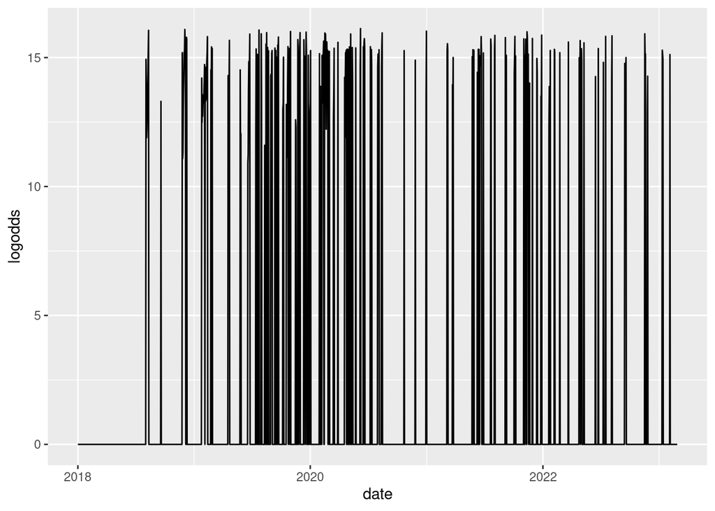

Logodds and counts over time

```r
ggplot(sfr_df, aes(x = date, y = logodds)) +
    geom_line()
```

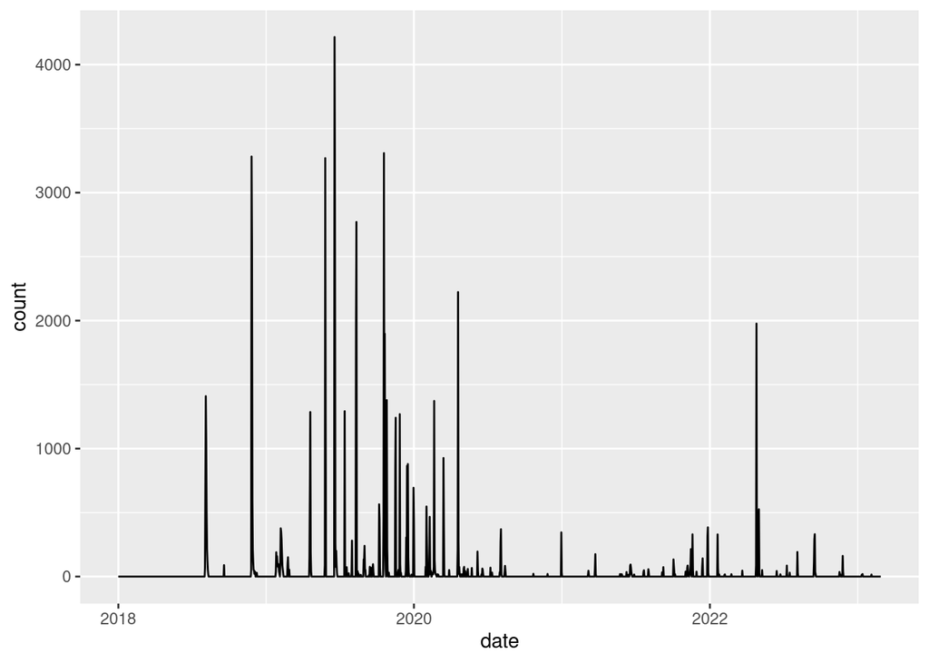

Logodds and counts over time

```r
ggplot(sfr_df, aes(x = date, y = count)) +
    geom_line()
```

# Time Series Decomposition

Applying Seasonal Trend Loess decomposition, we see a peak in the time series trend late 2019-early 2020. We see some reasonably consistent seasonality as well, that seems to contribute a decent amount to the variation in the data. Intuitively, very little in the twittersphere lasts more than a week so we’ll assume there isn’t much of a point in adding seasonality over a week.

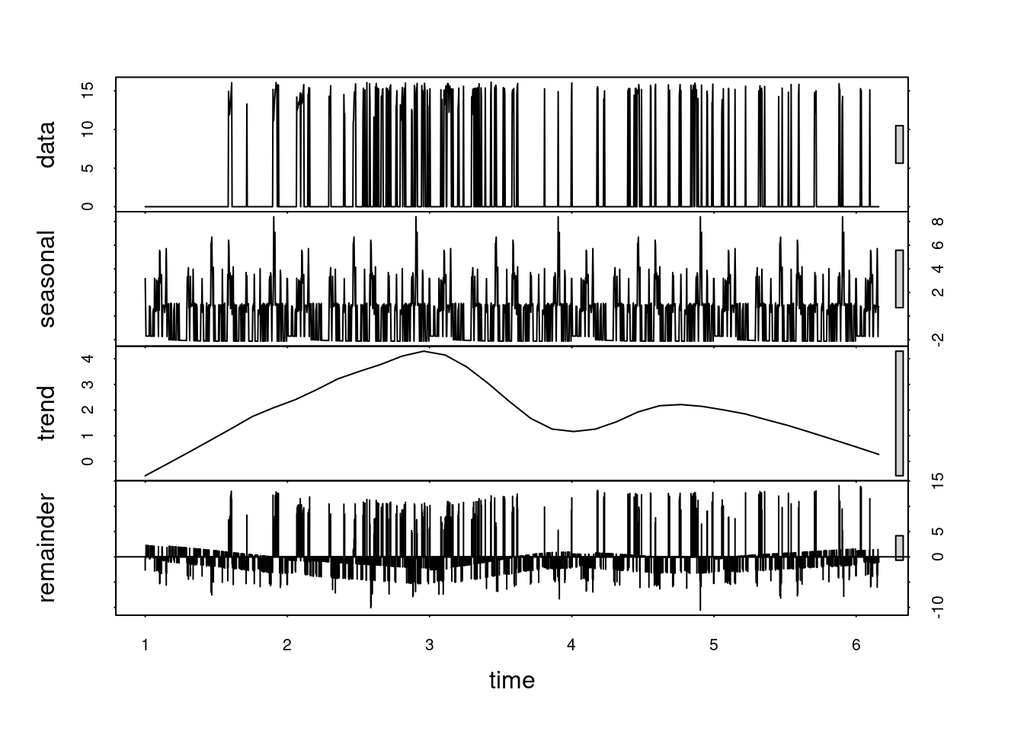

Seasonal, trend. and remainder decomposition

```r
sfr_df$logodds %>% ts(., frequency = 365) %>% stl(., s.window = "per") %>% plot(.)
```

# Forecasting Model

For the model specification, I decided on the following:

```r
model_components <- list()
model_components <- AddAutoAr(model_components, y = sfr_df$logodds)
model_components <- AddLocalLevel(model_components, y = sfr_df$logodds)
model_components <- AddSeasonal(model_components, y = sfr_df$logodds, nseasons = 52, season.duration = 7)
summary(model_components)
```

```
     Length Class      Mode
[1,] 4      AutoAr     list
[2,] 4      LocalLevel list
[3,] 6      Seasonal   list
```

```r
fit <- bsts(sfr_df$logodds, model_components, niter = 1000)
```

```
=-=-=-=-= Iteration 0 Sun Mar  5 19:40:02 2023 =-=-=-=-=
=-=-=-=-= Iteration 100 Sun Mar  5 19:40:11 2023 =-=-=-=-=
=-=-=-=-= Iteration 200 Sun Mar  5 19:40:21 2023 =-=-=-=-=
=-=-=-=-= Iteration 300 Sun Mar  5 19:40:31 2023 =-=-=-=-=
=-=-=-=-= Iteration 400 Sun Mar  5 19:40:42 2023 =-=-=-=-=
=-=-=-=-= Iteration 500 Sun Mar  5 19:40:52 2023 =-=-=-=-=
=-=-=-=-= Iteration 600 Sun Mar  5 19:41:02 2023 =-=-=-=-=
=-=-=-=-= Iteration 700 Sun Mar  5 19:41:12 2023 =-=-=-=-=
=-=-=-=-= Iteration 800 Sun Mar  5 19:41:22 2023 =-=-=-=-=
=-=-=-=-= Iteration 900 Sun Mar  5 19:41:32 2023 =-=-=-=-=
```

# Model Examination

Looking at the residual plot, the model seems to predict fairly well the variation in the data. There seems to be pretty good accuracy on the timescale end of things, though the magnitude of tweet spikes is a little harder to account for. The general trend in the data captures what we intuitively see from the initial data plot, with a spike in late 2019-early 2020 as well as another smaller uptick in early 2022. The model’s seasonality looks to be a good fit for the data, as the pattern of weekly changes in the data seems consistent when they’re removed from the trend component.

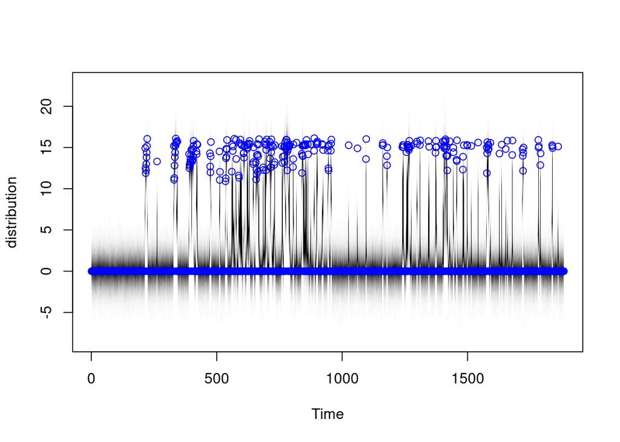

Residual, component, prediction error plots

```r
plot(fit)
```

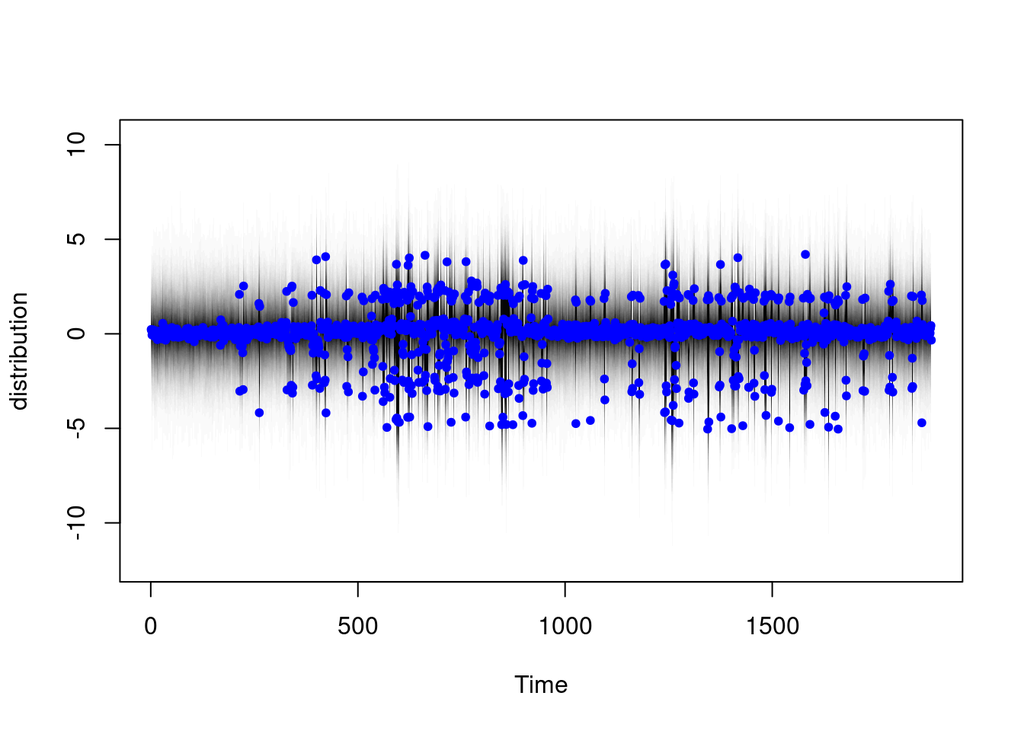

Residual, component, prediction error plots

```r
plot(fit, "residuals")
```

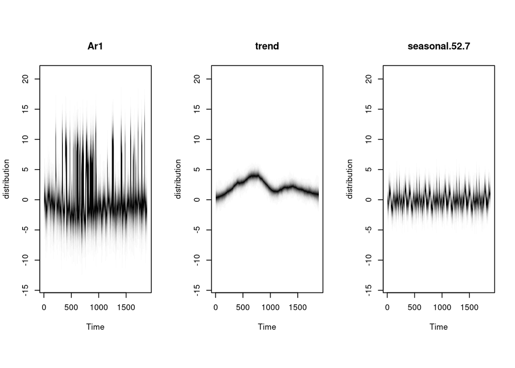

Residual, component, prediction error plots

```r
plot(fit, "components")
```

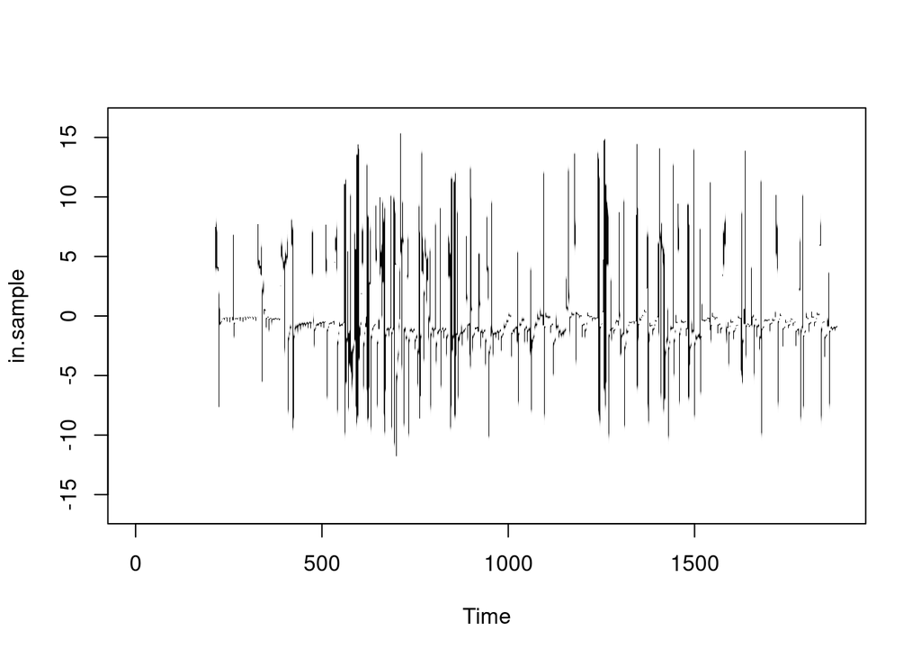

Residual, component, prediction error plots

```r
plot(fit, "prediction.errors")
```

Diving deeper into the contributions plots for each of the model components, the autoregressive component comes out as the highest contributor to model predictions. This intuitively makes sense in the sense that once someone decides to tweet or retweet something, its audience grows and ripples throughout the twittersphere, inspiring more and more tweets on the topic.

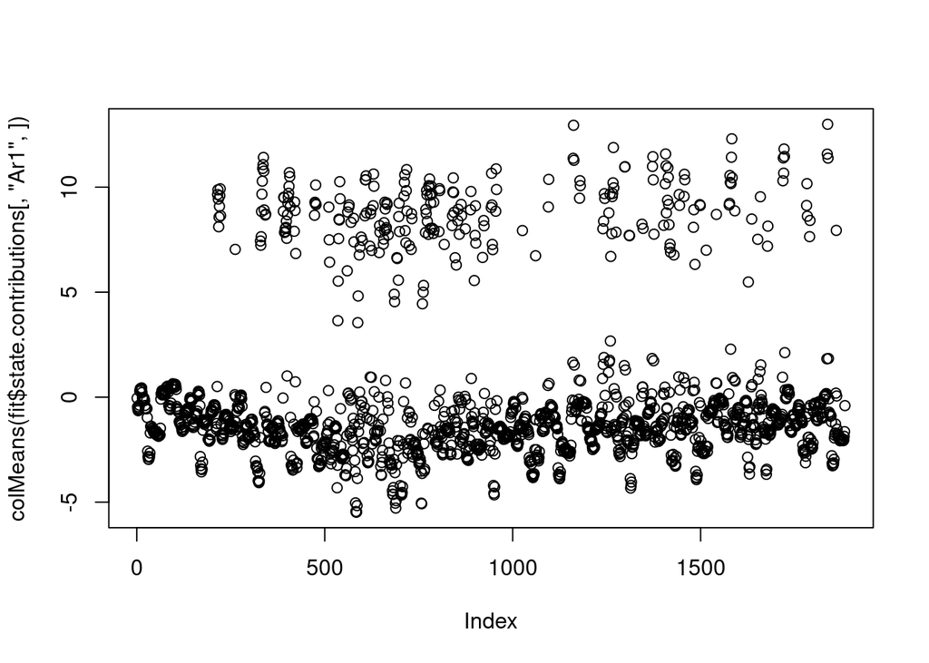

Autoregressive, trend, and weekly seasonal component contributions

```r
plot(colMeans(fit$state.contributions[,"Ar1",]))
```

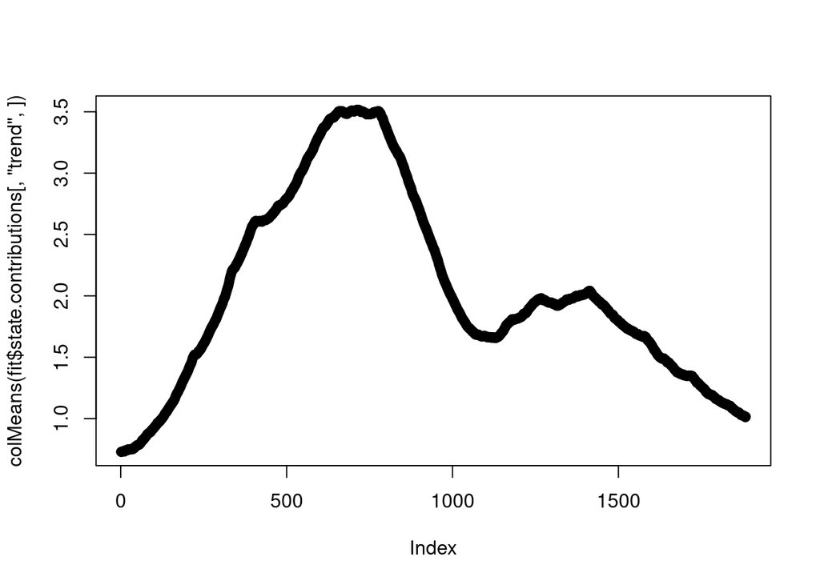

Autoregressive, trend, and weekly seasonal component contributions

```r
plot(colMeans(fit$state.contributions[,"trend",]))
```

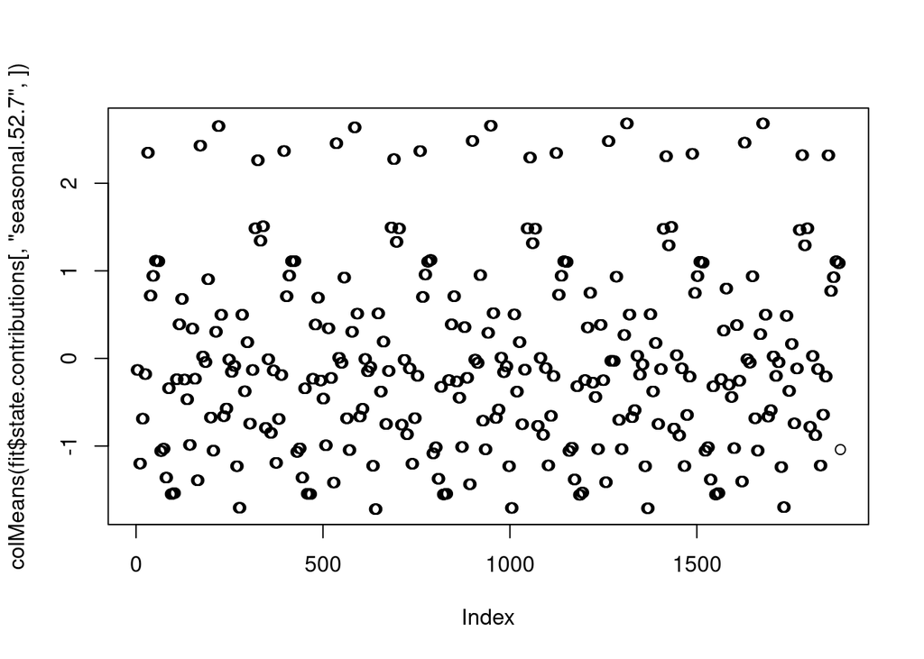

Autoregressive, trend, and weekly seasonal component contributions

```r
plot(colMeans(fit$state.contributions[,"seasonal.52.7",]))
```

# Conclusion

That being said, the predicted trend line does indicate some spikes in the next 180 days, and with the time of forecasting that would put a resurgence of “shrimp fried this rice” tweets in late Summer-early Fall, 2023. I, for one, will be awaiting this resurgence with the utmost excitement.

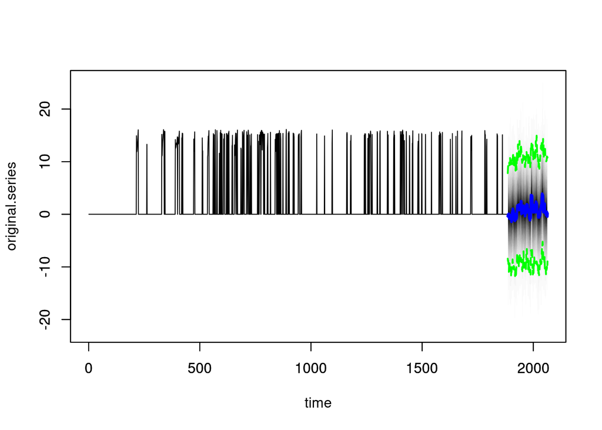

Logodds predictions for 180 days

```r
pred <- predict(fit, horizon = 180, quantiles = c(.05, .95))
plot(pred)
```